# GraceLi_A1

Grace Li

12/05/2021

# For Electrical

Read files from electricity consumption.

[output not shown]

[output cut: 57 more lines]

Categorize the electrical data into commercial(com) and residential(res), since we’ll be needing those for the graph.

# For Gas

Read file for gas.

[output not shown]

[output cut: 21 more lines]

Bind gas and elec data together and create the datasets “monthly commercial gas and electricity usage” and “monthly residential gas and electricity usage”

# Plot graph for commercial.

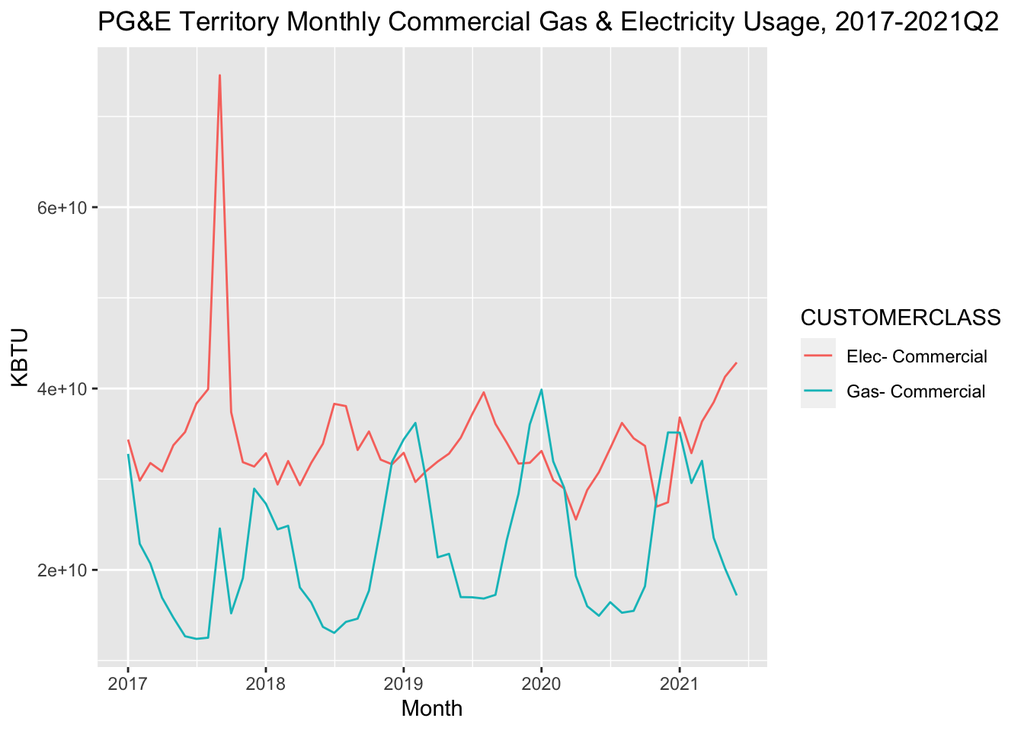

# Plot graph for residential.

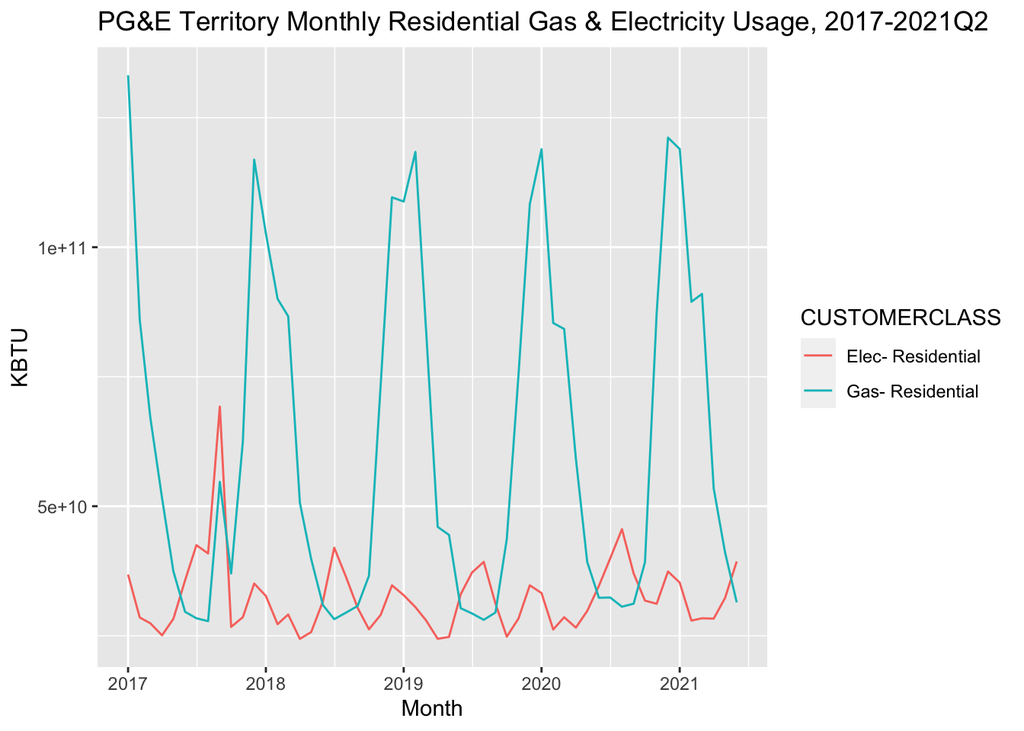

# Reflections

To visualize the change in commercial energy usage, we can create a line graph from 2019 to 2020.

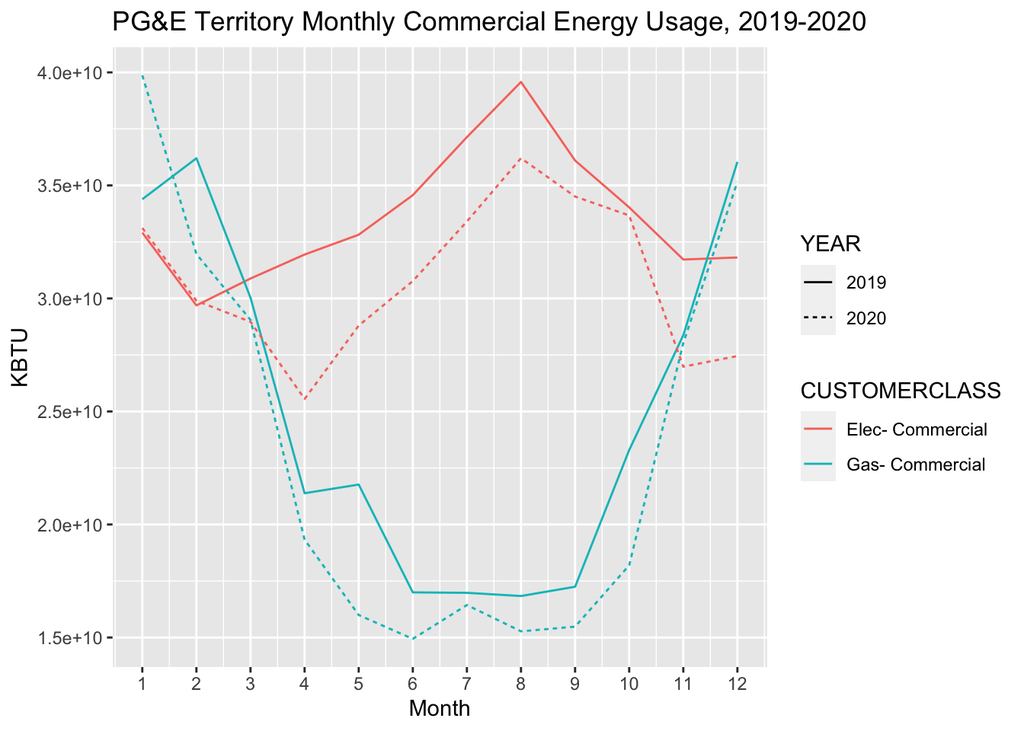

From the graph, we can see that commercial electricity use plummeted in April, 2020, just when the pandemic was making a huge impact across the country, contrary to the steady growth in 2019.There was also a sharp decline in the same period in commercial gas usage. Both electricity and gas usage then slowly begins to climb up to pre-pandemic levels, as companies an stores adjusted to this new norm and reopened.

Similarly, we can also create a graph for residential energy usage in 2019 and 2020

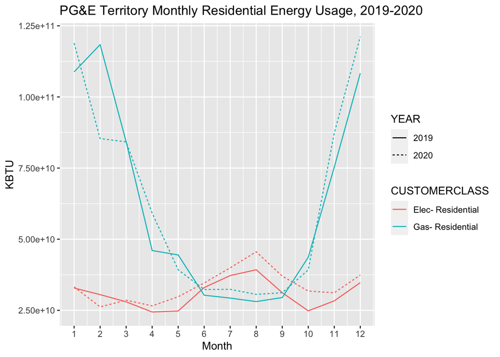

From this graph, we can see that the trend has not very much altered in 2020, suggesting that residential energy use was not very affected by the pandemic. The energy usage pattern continued to show a higher usage of gas in the winter months and electricity in summer months.